# Risk Factor Analysis

## Outcome Variable

**Outcome Variable:** ever_wasted

## Predictor Variables

**Intervention Variable:** hhwealth_quart

**Adjustment Set:**

- arm
- sex
- W_mage
- meducyrs
- feducyrs
- W_gagebrth
- W_birthwt
- W_birthlen
- W_nchldlt5
- W_parity
- delta_W_mage
- delta_meducyrs
- delta_feducyrs
- delta_W_gagebrth
- delta_W_birthwt
- delta_W_birthlen
- delta_W_nchldlt5
- delta_W_parity

## Stratifying Variables

The analysis was stratified on these variable(s):

- agecat
- studyid
- country

## Data Summary

| agecat | studyid | country | hhwealth_quart | ever_wasted | n_cell | n |
| --- | --- | --- | --- | --- | --- | --- |
| 0-24 months | CMC-V-BCS-2002 | INDIA | Wealth Q4 | 0 | 44 | 373 |
| 0-24 months | CMC-V-BCS-2002 | INDIA | Wealth Q4 | 1 | 52 | 373 |
| 0-24 months | CMC-V-BCS-2002 | INDIA | Wealth Q1 | 0 | 37 | 373 |
| 0-24 months | CMC-V-BCS-2002 | INDIA | Wealth Q1 | 1 | 54 | 373 |
| 0-24 months | CMC-V-BCS-2002 | INDIA | Wealth Q2 | 0 | 26 | 373 |
| 0-24 months | CMC-V-BCS-2002 | INDIA | Wealth Q2 | 1 | 69 | 373 |
| 0-24 months | CMC-V-BCS-2002 | INDIA | Wealth Q3 | 0 | 38 | 373 |
| 0-24 months | CMC-V-BCS-2002 | INDIA | Wealth Q3 | 1 | 53 | 373 |
| 0-24 months | COHORTS | GUATEMALA | Wealth Q4 | 0 | 366 | 1263 |
| 0-24 months | COHORTS | GUATEMALA | Wealth Q4 | 1 | 110 | 1263 |
| 0-24 months | COHORTS | GUATEMALA | Wealth Q1 | 0 | 166 | 1263 |
| 0-24 months | COHORTS | GUATEMALA | Wealth Q1 | 1 | 78 | 1263 |
| 0-24 months | COHORTS | GUATEMALA | Wealth Q2 | 0 | 190 | 1263 |
| 0-24 months | COHORTS | GUATEMALA | Wealth Q2 | 1 | 68 | 1263 |
| 0-24 months | COHORTS | GUATEMALA | Wealth Q3 | 0 | 211 | 1263 |
| 0-24 months | COHORTS | GUATEMALA | Wealth Q3 | 1 | 74 | 1263 |
| 0-24 months | COHORTS | PHILIPPINES | Wealth Q4 | 0 | 531 | 3044 |
| 0-24 months | COHORTS | PHILIPPINES | Wealth Q4 | 1 | 309 | 3044 |
| 0-24 months | COHORTS | PHILIPPINES | Wealth Q1 | 0 | 372 | 3044 |
| 0-24 months | COHORTS | PHILIPPINES | Wealth Q1 | 1 | 309 | 3044 |
| 0-24 months | COHORTS | PHILIPPINES | Wealth Q2 | 0 | 330 | 3044 |
| 0-24 months | COHORTS | PHILIPPINES | Wealth Q2 | 1 | 210 | 3044 |
| 0-24 months | COHORTS | PHILIPPINES | Wealth Q3 | 0 | 582 | 3044 |
| 0-24 months | COHORTS | PHILIPPINES | Wealth Q3 | 1 | 401 | 3044 |
| 0-24 months | CONTENT | PERU | Wealth Q4 | 0 | 50 | 215 |
| 0-24 months | CONTENT | PERU | Wealth Q4 | 1 | 2 | 215 |
| 0-24 months | CONTENT | PERU | Wealth Q1 | 0 | 58 | 215 |
| 0-24 months | CONTENT | PERU | Wealth Q1 | 1 | 1 | 215 |
| 0-24 months | CONTENT | PERU | Wealth Q2 | 0 | 50 | 215 |
| 0-24 months | CONTENT | PERU | Wealth Q2 | 1 | 2 | 215 |

[output cut: 402 more lines]

The following strata were considered:

- agecat: 0-24 months, studyid: CMC-V-BCS-2002, country: INDIA
- agecat: 0-24 months, studyid: COHORTS, country: GUATEMALA
- agecat: 0-24 months, studyid: COHORTS, country: PHILIPPINES
- agecat: 0-24 months, studyid: CONTENT, country: PERU
- agecat: 0-24 months, studyid: GMS-Nepal, country: NEPAL
- agecat: 0-24 months, studyid: IRC, country: INDIA
- agecat: 0-24 months, studyid: JiVitA-3, country: BANGLADESH
- agecat: 0-24 months, studyid: JiVitA-4, country: BANGLADESH
- agecat: 0-24 months, studyid: LCNI-5, country: MALAWI
- agecat: 0-24 months, studyid: MAL-ED, country: BANGLADESH
- agecat: 0-24 months, studyid: MAL-ED, country: BRAZIL
- agecat: 0-24 months, studyid: MAL-ED, country: INDIA
- agecat: 0-24 months, studyid: MAL-ED, country: NEPAL
- agecat: 0-24 months, studyid: MAL-ED, country: PERU
- agecat: 0-24 months, studyid: MAL-ED, country: SOUTH AFRICA
- agecat: 0-24 months, studyid: MAL-ED, country: TANZANIA, UNITED REPUBLIC OF
- agecat: 0-24 months, studyid: PROVIDE, country: BANGLADESH
- agecat: 0-24 months, studyid: TanzaniaChild2, country: TANZANIA, UNITED REPUBLIC OF
- agecat: 0-6 months, studyid: CMC-V-BCS-2002, country: INDIA
- agecat: 0-6 months, studyid: COHORTS, country: GUATEMALA
- agecat: 0-6 months, studyid: COHORTS, country: PHILIPPINES
- agecat: 0-6 months, studyid: CONTENT, country: PERU
- agecat: 0-6 months, studyid: GMS-Nepal, country: NEPAL
- agecat: 0-6 months, studyid: IRC, country: INDIA
- agecat: 0-6 months, studyid: JiVitA-3, country: BANGLADESH
- agecat: 0-6 months, studyid: JiVitA-4, country: BANGLADESH
- agecat: 0-6 months, studyid: LCNI-5, country: MALAWI
- agecat: 0-6 months, studyid: MAL-ED, country: BANGLADESH
- agecat: 0-6 months, studyid: MAL-ED, country: BRAZIL
- agecat: 0-6 months, studyid: MAL-ED, country: INDIA
- agecat: 0-6 months, studyid: MAL-ED, country: NEPAL
- agecat: 0-6 months, studyid: MAL-ED, country: PERU
- agecat: 0-6 months, studyid: MAL-ED, country: SOUTH AFRICA
- agecat: 0-6 months, studyid: MAL-ED, country: TANZANIA, UNITED REPUBLIC OF
- agecat: 0-6 months, studyid: PROVIDE, country: BANGLADESH
- agecat: 0-6 months, studyid: TanzaniaChild2, country: TANZANIA, UNITED REPUBLIC OF
- agecat: 6-24 months, studyid: CMC-V-BCS-2002, country: INDIA
- agecat: 6-24 months, studyid: COHORTS, country: GUATEMALA
- agecat: 6-24 months, studyid: COHORTS, country: PHILIPPINES
- agecat: 6-24 months, studyid: CONTENT, country: PERU
- agecat: 6-24 months, studyid: GMS-Nepal, country: NEPAL
- agecat: 6-24 months, studyid: IRC, country: INDIA
- agecat: 6-24 months, studyid: JiVitA-3, country: BANGLADESH
- agecat: 6-24 months, studyid: JiVitA-4, country: BANGLADESH
- agecat: 6-24 months, studyid: LCNI-5, country: MALAWI
- agecat: 6-24 months, studyid: MAL-ED, country: BANGLADESH
- agecat: 6-24 months, studyid: MAL-ED, country: BRAZIL
- agecat: 6-24 months, studyid: MAL-ED, country: INDIA
- agecat: 6-24 months, studyid: MAL-ED, country: NEPAL
- agecat: 6-24 months, studyid: MAL-ED, country: PERU
- agecat: 6-24 months, studyid: MAL-ED, country: SOUTH AFRICA
- agecat: 6-24 months, studyid: MAL-ED, country: TANZANIA, UNITED REPUBLIC OF
- agecat: 6-24 months, studyid: PROVIDE, country: BANGLADESH
- agecat: 6-24 months, studyid: TanzaniaChild2, country: TANZANIA, UNITED REPUBLIC OF

### Dropped Strata

Some strata were dropped due to rare outcomes:

- agecat: 0-24 months, studyid: CONTENT, country: PERU
- agecat: 0-24 months, studyid: MAL-ED, country: BRAZIL
- agecat: 0-6 months, studyid: CONTENT, country: PERU
- agecat: 0-6 months, studyid: LCNI-5, country: MALAWI
- agecat: 0-6 months, studyid: MAL-ED, country: BRAZIL
- agecat: 0-6 months, studyid: MAL-ED, country: PERU
- agecat: 0-6 months, studyid: MAL-ED, country: TANZANIA, UNITED REPUBLIC OF
- agecat: 6-24 months, studyid: CONTENT, country: PERU
- agecat: 6-24 months, studyid: MAL-ED, country: BRAZIL
- agecat: 6-24 months, studyid: MAL-ED, country: PERU
- agecat: 6-24 months, studyid: MAL-ED, country: TANZANIA, UNITED REPUBLIC OF

## Methods Detail

We’re interested in the causal parameters $E[Y_a]$ for all values of $a \in \mathcal{A}$. These parameters represent the mean outcome if, possibly contrary to fact, we intervened to set all units to have $A=a$. Under the randomization and positivity assumptions, these are identified by the statistical parameters $\psi_a=E_W[E_{Y|A,W}(Y|A=a,W)]$. In addition, we’re interested in the mean of $Y$, $E[Y]$ under no intervention (the observed mean). We will estimate these parameters by using SuperLearner to fit the relevant likelihood factors – $E_{Y|A,W}(Y|A=a,W)$ and $p(A=a|W)$, and then updating our likelihood fit using a joint TMLE.

For unadjusted analyses ($W=\{\}$), initial likelihoods were estimated using Lrnr_glm to estimate the simple $E(Y|A)$ and Lrnr_mean to estimate $p(A)$. For adjusted analyses, a small library containing Lrnr_glmnet, Lrnr_xgboost, and Lrnr_mean was used.

Having estimated these parameters, we will then use the delta method to estimate relative risks and attributable risks relative to a prespecified baseline level of $A$.

# Results Detail

## Results Plots

[figure not shown]

[figure not shown]

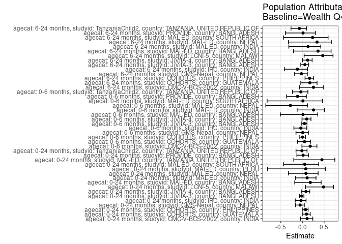

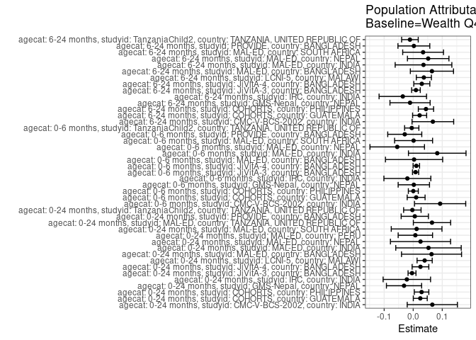

## Results Table

### Parameter: TSM

| agecat | studyid | country | intervention_level | baseline_level | estimate | ci_lower | ci_upper |
| --- | --- | --- | --- | --- | --- | --- | --- |
| 0-24 months | CMC-V-BCS-2002 | INDIA | Wealth Q4 | NA | 0.5455358 | 0.4446693 | 0.6464023 |
| 0-24 months | CMC-V-BCS-2002 | INDIA | Wealth Q1 | NA | 0.5990871 | 0.4966389 | 0.7015353 |
| 0-24 months | CMC-V-BCS-2002 | INDIA | Wealth Q2 | NA | 0.7304834 | 0.6405683 | 0.8203985 |
| 0-24 months | CMC-V-BCS-2002 | INDIA | Wealth Q3 | NA | 0.5699686 | 0.4678100 | 0.6721272 |
| 0-24 months | COHORTS | GUATEMALA | Wealth Q4 | NA | 0.2370561 | 0.2049865 | 0.2691257 |
| 0-24 months | COHORTS | GUATEMALA | Wealth Q1 | NA | 0.3048543 | 0.2542119 | 0.3554967 |
| 0-24 months | COHORTS | GUATEMALA | Wealth Q2 | NA | 0.2642762 | 0.2153645 | 0.3131878 |
| 0-24 months | COHORTS | GUATEMALA | Wealth Q3 | NA | 0.2575865 | 0.2109195 | 0.3042535 |
| 0-24 months | COHORTS | PHILIPPINES | Wealth Q4 | NA | 0.3749962 | 0.3453818 | 0.4046105 |
| 0-24 months | COHORTS | PHILIPPINES | Wealth Q1 | NA | 0.4364275 | 0.4004702 | 0.4723848 |
| 0-24 months | COHORTS | PHILIPPINES | Wealth Q2 | NA | 0.3880126 | 0.3484069 | 0.4276183 |
| 0-24 months | COHORTS | PHILIPPINES | Wealth Q3 | NA | 0.4111744 | 0.3825076 | 0.4398413 |
| 0-24 months | GMS-Nepal | NEPAL | Wealth Q4 | NA | 0.6220648 | 0.5507420 | 0.6933875 |
| 0-24 months | GMS-Nepal | NEPAL | Wealth Q1 | NA | 0.5544075 | 0.4860414 | 0.6227737 |
| 0-24 months | GMS-Nepal | NEPAL | Wealth Q2 | NA | 0.5950773 | 0.5266019 | 0.6635528 |
| 0-24 months | GMS-Nepal | NEPAL | Wealth Q3 | NA | 0.5899022 | 0.5193765 | 0.6604279 |
| 0-24 months | IRC | INDIA | Wealth Q4 | NA | 0.6781078 | 0.5844127 | 0.7718029 |
| 0-24 months | IRC | INDIA | Wealth Q1 | NA | 0.6734600 | 0.5838723 | 0.7630477 |
| 0-24 months | IRC | INDIA | Wealth Q2 | NA | 0.6001070 | 0.5046752 | 0.6955388 |
| 0-24 months | IRC | INDIA | Wealth Q3 | NA | 0.6881624 | 0.5972657 | 0.7790591 |
| 0-24 months | JiVitA-3 | BANGLADESH | Wealth Q4 | NA | 0.2621551 | 0.2469845 | 0.2773256 |
| 0-24 months | JiVitA-3 | BANGLADESH | Wealth Q1 | NA | 0.2592370 | 0.2457890 | 0.2726851 |
| 0-24 months | JiVitA-3 | BANGLADESH | Wealth Q2 | NA | 0.2552819 | 0.2429921 | 0.2675718 |
| 0-24 months | JiVitA-3 | BANGLADESH | Wealth Q3 | NA | 0.2601097 | 0.2484935 | 0.2717259 |
| 0-24 months | JiVitA-4 | BANGLADESH | Wealth Q4 | NA | 0.2851871 | 0.2547883 | 0.3155858 |
| 0-24 months | JiVitA-4 | BANGLADESH | Wealth Q1 | NA | 0.3391182 | 0.3116733 | 0.3665631 |
| 0-24 months | JiVitA-4 | BANGLADESH | Wealth Q2 | NA | 0.3263083 | 0.2956178 | 0.3569987 |
| 0-24 months | JiVitA-4 | BANGLADESH | Wealth Q3 | NA | 0.2925840 | 0.2634354 | 0.3217325 |
| 0-24 months | LCNI-5 | MALAWI | Wealth Q4 | NA | 0.0414747 | 0.0149300 | 0.0680193 |
| 0-24 months | LCNI-5 | MALAWI | Wealth Q1 | NA | 0.1176471 | 0.0734075 | 0.1618866 |

[output cut: 142 more lines]

### Parameter: E(Y)

| agecat | studyid | country | intervention_level | baseline_level | estimate | ci_lower | ci_upper |
| --- | --- | --- | --- | --- | --- | --- | --- |
| 0-24 months | CMC-V-BCS-2002 | INDIA | NA | NA | 0.6112601 | 0.5617242 | 0.6607959 |
| 0-24 months | COHORTS | GUATEMALA | NA | NA | 0.2612827 | 0.2370438 | 0.2855216 |
| 0-24 months | COHORTS | PHILIPPINES | NA | NA | 0.4037451 | 0.3863123 | 0.4211779 |
| 0-24 months | GMS-Nepal | NEPAL | NA | NA | 0.5903790 | 0.5535526 | 0.6272054 |
| 0-24 months | IRC | INDIA | NA | NA | 0.6560976 | 0.6100625 | 0.7021326 |
| 0-24 months | JiVitA-3 | BANGLADESH | NA | NA | 0.2579831 | 0.2515145 | 0.2644516 |
| 0-24 months | JiVitA-4 | BANGLADESH | NA | NA | 0.3101161 | 0.2957091 | 0.3245231 |
| 0-24 months | LCNI-5 | MALAWI | NA | NA | 0.0807834 | 0.0620863 | 0.0994804 |
| 0-24 months | MAL-ED | BANGLADESH | NA | NA | 0.3471074 | 0.2870050 | 0.4072099 |
| 0-24 months | MAL-ED | INDIA | NA | NA | 0.4851064 | 0.4210714 | 0.5491414 |
| 0-24 months | MAL-ED | NEPAL | NA | NA | 0.3093220 | 0.2502261 | 0.3684179 |
| 0-24 months | MAL-ED | PERU | NA | NA | 0.0955882 | 0.0605817 | 0.1305947 |
| 0-24 months | MAL-ED | SOUTH AFRICA | NA | NA | 0.2217899 | 0.1708981 | 0.2726816 |
| 0-24 months | MAL-ED | TANZANIA, UNITED REPUBLIC OF | NA | NA | 0.1440000 | 0.1003920 | 0.1876080 |
| 0-24 months | PROVIDE | BANGLADESH | NA | NA | 0.3514286 | 0.3160364 | 0.3868207 |
| 0-24 months | TanzaniaChild2 | TANZANIA, UNITED REPUBLIC OF | NA | NA | 0.2365772 | 0.2195142 | 0.2536402 |
| 0-6 months | CMC-V-BCS-2002 | INDIA | NA | NA | 0.5163043 | 0.4651769 | 0.5674318 |
| 0-6 months | COHORTS | GUATEMALA | NA | NA | 0.2029557 | 0.1782002 | 0.2277111 |
| 0-6 months | COHORTS | PHILIPPINES | NA | NA | 0.2356227 | 0.2205417 | 0.2507038 |
| 0-6 months | GMS-Nepal | NEPAL | NA | NA | 0.3760933 | 0.3398180 | 0.4123685 |
| 0-6 months | IRC | INDIA | NA | NA | 0.5439024 | 0.4956326 | 0.5921723 |
| 0-6 months | JiVitA-3 | BANGLADESH | NA | NA | 0.1761878 | 0.1705589 | 0.1818167 |
| 0-6 months | JiVitA-4 | BANGLADESH | NA | NA | 0.1078103 | 0.0979894 | 0.1176312 |
| 0-6 months | MAL-ED | BANGLADESH | NA | NA | 0.2355372 | 0.1819640 | 0.2891104 |
| 0-6 months | MAL-ED | INDIA | NA | NA | 0.3234043 | 0.2634696 | 0.3833389 |
| 0-6 months | MAL-ED | NEPAL | NA | NA | 0.1991525 | 0.1480924 | 0.2502127 |
| 0-6 months | MAL-ED | SOUTH AFRICA | NA | NA | 0.1089494 | 0.0707821 | 0.1471167 |
| 0-6 months | PROVIDE | BANGLADESH | NA | NA | 0.2585714 | 0.2261125 | 0.2910304 |
| 0-6 months | TanzaniaChild2 | TANZANIA, UNITED REPUBLIC OF | NA | NA | 0.1392617 | 0.1253610 | 0.1531625 |
| 6-24 months | CMC-V-BCS-2002 | INDIA | NA | NA | 0.2654155 | 0.2205451 | 0.3102860 |
| 6-24 months | COHORTS | GUATEMALA | NA | NA | 0.1291161 | 0.1097606 | 0.1484716 |
| 6-24 months | COHORTS | PHILIPPINES | NA | NA | 0.2666429 | 0.2502871 | 0.2829988 |
| 6-24 months | GMS-Nepal | NEPAL | NA | NA | 0.4728814 | 0.4325613 | 0.5132014 |
| 6-24 months | IRC | INDIA | NA | NA | 0.3097561 | 0.2649438 | 0.3545684 |
| 6-24 months | JiVitA-3 | BANGLADESH | NA | NA | 0.1638036 | 0.1576801 | 0.1699271 |
| 6-24 months | JiVitA-4 | BANGLADESH | NA | NA | 0.2472801 | 0.2337480 | 0.2608122 |
| 6-24 months | LCNI-5 | MALAWI | NA | NA | 0.0782609 | 0.0596958 | 0.0968259 |
| 6-24 months | MAL-ED | BANGLADESH | NA | NA | 0.1791667 | 0.1305478 | 0.2277856 |
| 6-24 months | MAL-ED | INDIA | NA | NA | 0.2723404 | 0.2153029 | 0.3293779 |
| 6-24 months | MAL-ED | NEPAL | NA | NA | 0.1531915 | 0.1070438 | 0.1993392 |
| 6-24 months | MAL-ED | SOUTH AFRICA | NA | NA | 0.1450980 | 0.1017849 | 0.1884112 |
| 6-24 months | PROVIDE | BANGLADESH | NA | NA | 0.1609756 | 0.1319065 | 0.1900447 |
| 6-24 months | TanzaniaChild2 | TANZANIA, UNITED REPUBLIC OF | NA | NA | 0.1606965 | 0.1446374 | 0.1767556 |

### Parameter: RR

| agecat | studyid | country | intervention_level | baseline_level | estimate | ci_lower | ci_upper |
| --- | --- | --- | --- | --- | --- | --- | --- |
| 0-24 months | CMC-V-BCS-2002 | INDIA | Wealth Q4 | Wealth Q4 | 1.0000000 | 1.0000000 | 1.0000000 |
| 0-24 months | CMC-V-BCS-2002 | INDIA | Wealth Q1 | Wealth Q4 | 1.0981628 | 0.8533840 | 1.4131522 |
| 0-24 months | CMC-V-BCS-2002 | INDIA | Wealth Q2 | Wealth Q4 | 1.3390202 | 1.0732591 | 1.6705892 |
| 0-24 months | CMC-V-BCS-2002 | INDIA | Wealth Q3 | Wealth Q4 | 1.0447868 | 0.8075680 | 1.3516874 |
| 0-24 months | COHORTS | GUATEMALA | Wealth Q4 | Wealth Q4 | 1.0000000 | 1.0000000 | 1.0000000 |
| 0-24 months | COHORTS | GUATEMALA | Wealth Q1 | Wealth Q4 | 1.2860007 | 1.0543615 | 1.5685301 |
| 0-24 months | COHORTS | GUATEMALA | Wealth Q2 | Wealth Q4 | 1.1148254 | 0.8992210 | 1.3821249 |
| 0-24 months | COHORTS | GUATEMALA | Wealth Q3 | Wealth Q4 | 1.0866057 | 0.8800675 | 1.3416152 |
| 0-24 months | COHORTS | PHILIPPINES | Wealth Q4 | Wealth Q4 | 1.0000000 | 1.0000000 | 1.0000000 |
| 0-24 months | COHORTS | PHILIPPINES | Wealth Q1 | Wealth Q4 | 1.1638186 | 1.0420781 | 1.2997813 |
| 0-24 months | COHORTS | PHILIPPINES | Wealth Q2 | Wealth Q4 | 1.0347107 | 0.9126855 | 1.1730507 |
| 0-24 months | COHORTS | PHILIPPINES | Wealth Q3 | Wealth Q4 | 1.0964763 | 0.9913662 | 1.2127307 |
| 0-24 months | GMS-Nepal | NEPAL | Wealth Q4 | Wealth Q4 | 1.0000000 | 1.0000000 | 1.0000000 |
| 0-24 months | GMS-Nepal | NEPAL | Wealth Q1 | Wealth Q4 | 0.8912376 | 0.7558529 | 1.0508718 |
| 0-24 months | GMS-Nepal | NEPAL | Wealth Q2 | Wealth Q4 | 0.9566163 | 0.8163615 | 1.1209676 |
| 0-24 months | GMS-Nepal | NEPAL | Wealth Q3 | Wealth Q4 | 0.9482970 | 0.8061307 | 1.1155353 |
| 0-24 months | IRC | INDIA | Wealth Q4 | Wealth Q4 | 1.0000000 | 1.0000000 | 1.0000000 |
| 0-24 months | IRC | INDIA | Wealth Q1 | Wealth Q4 | 0.9931460 | 0.8199218 | 1.2029671 |
| 0-24 months | IRC | INDIA | Wealth Q2 | Wealth Q4 | 0.8849730 | 0.7170618 | 1.0922031 |
| 0-24 months | IRC | INDIA | Wealth Q3 | Wealth Q4 | 1.0148274 | 0.8380353 | 1.2289156 |
| 0-24 months | JiVitA-3 | BANGLADESH | Wealth Q4 | Wealth Q4 | 1.0000000 | 1.0000000 | 1.0000000 |
| 0-24 months | JiVitA-3 | BANGLADESH | Wealth Q1 | Wealth Q4 | 0.9888691 | 0.9174682 | 1.0658267 |
| 0-24 months | JiVitA-3 | BANGLADESH | Wealth Q2 | Wealth Q4 | 0.9737823 | 0.9075147 | 1.0448888 |
| 0-24 months | JiVitA-3 | BANGLADESH | Wealth Q3 | Wealth Q4 | 0.9921980 | 0.9245242 | 1.0648254 |
| 0-24 months | JiVitA-4 | BANGLADESH | Wealth Q4 | Wealth Q4 | 1.0000000 | 1.0000000 | 1.0000000 |
| 0-24 months | JiVitA-4 | BANGLADESH | Wealth Q1 | Wealth Q4 | 1.1891078 | 1.0415182 | 1.3576119 |
| 0-24 months | JiVitA-4 | BANGLADESH | Wealth Q2 | Wealth Q4 | 1.1441902 | 0.9941009 | 1.3169399 |
| 0-24 months | JiVitA-4 | BANGLADESH | Wealth Q3 | Wealth Q4 | 1.0259371 | 0.8868007 | 1.1869035 |
| 0-24 months | LCNI-5 | MALAWI | Wealth Q4 | Wealth Q4 | 1.0000000 | 1.0000000 | 1.0000000 |
| 0-24 months | LCNI-5 | MALAWI | Wealth Q1 | Wealth Q4 | 2.8366013 | 1.3502532 | 5.9591095 |

[output cut: 142 more lines]

### Parameter: PAR

| agecat | studyid | country | intervention_level | baseline_level | estimate | ci_lower | ci_upper |
| --- | --- | --- | --- | --- | --- | --- | --- |
| 0-24 months | CMC-V-BCS-2002 | INDIA | Wealth Q4 | NA | 0.0657243 | -0.0207044 | 0.1521529 |
| 0-24 months | COHORTS | GUATEMALA | Wealth Q4 | NA | 0.0242266 | 0.0002548 | 0.0481983 |
| 0-24 months | COHORTS | PHILIPPINES | Wealth Q4 | NA | 0.0287489 | 0.0037519 | 0.0537459 |
| 0-24 months | GMS-Nepal | NEPAL | Wealth Q4 | NA | -0.0316858 | -0.0922722 | 0.0289006 |
| 0-24 months | IRC | INDIA | Wealth Q4 | NA | -0.0220102 | -0.1036889 | 0.0596685 |
| 0-24 months | JiVitA-3 | BANGLADESH | Wealth Q4 | NA | -0.0041720 | -0.0178066 | 0.0094626 |
| 0-24 months | JiVitA-4 | BANGLADESH | Wealth Q4 | NA | 0.0249290 | -0.0038255 | 0.0536835 |
| 0-24 months | LCNI-5 | MALAWI | Wealth Q4 | NA | 0.0393087 | 0.0132339 | 0.0653835 |
| 0-24 months | MAL-ED | BANGLADESH | Wealth Q4 | NA | 0.0630330 | -0.0403283 | 0.1663943 |
| 0-24 months | MAL-ED | INDIA | Wealth Q4 | NA | 0.0525692 | -0.0601217 | 0.1652601 |
| 0-24 months | MAL-ED | NEPAL | Wealth Q4 | NA | 0.0250739 | -0.0784742 | 0.1286221 |
| 0-24 months | MAL-ED | PERU | Wealth Q4 | NA | 0.0073529 | -0.0518605 | 0.0665664 |
| 0-24 months | MAL-ED | SOUTH AFRICA | Wealth Q4 | NA | 0.0116700 | -0.0756232 | 0.0989631 |
| 0-24 months | MAL-ED | TANZANIA, UNITED REPUBLIC OF | Wealth Q4 | NA | 0.0646349 | 0.0004450 | 0.1288248 |
| 0-24 months | PROVIDE | BANGLADESH | Wealth Q4 | NA | 0.0054377 | -0.0415382 | 0.0524136 |
| 0-24 months | TanzaniaChild2 | TANZANIA, UNITED REPUBLIC OF | Wealth Q4 | NA | -0.0030097 | -0.0330363 | 0.0270170 |
| 0-6 months | CMC-V-BCS-2002 | INDIA | Wealth Q4 | NA | 0.0925975 | 0.0044495 | 0.1807455 |
| 0-6 months | COHORTS | GUATEMALA | Wealth Q4 | NA | 0.0099974 | -0.0208003 | 0.0407952 |
| 0-6 months | COHORTS | PHILIPPINES | Wealth Q4 | NA | 0.0003217 | -0.0168105 | 0.0174539 |
| 0-6 months | GMS-Nepal | NEPAL | Wealth Q4 | NA | 0.0020835 | -0.0518830 | 0.0560499 |
| 0-6 months | IRC | INDIA | Wealth Q4 | NA | -0.0201622 | -0.1009423 | 0.0606180 |
| 0-6 months | JiVitA-3 | BANGLADESH | Wealth Q4 | NA | 0.0081102 | -0.0024919 | 0.0187123 |
| 0-6 months | JiVitA-4 | BANGLADESH | Wealth Q4 | NA | 0.0106910 | -0.0004488 | 0.0218307 |
| 0-6 months | MAL-ED | BANGLADESH | Wealth Q4 | NA | 0.0029153 | -0.0955318 | 0.1013624 |
| 0-6 months | MAL-ED | INDIA | Wealth Q4 | NA | 0.0826687 | -0.0164292 | 0.1817665 |
| 0-6 months | MAL-ED | NEPAL | Wealth Q4 | NA | -0.0550847 | -0.1489240 | 0.0387545 |
| 0-6 months | MAL-ED | SOUTH AFRICA | Wealth Q4 | NA | 0.0012571 | -0.0641197 | 0.0666339 |
| 0-6 months | PROVIDE | BANGLADESH | Wealth Q4 | NA | -0.0291703 | -0.0877689 | 0.0294283 |
| 0-6 months | TanzaniaChild2 | TANZANIA, UNITED REPUBLIC OF | Wealth Q4 | NA | -0.0051309 | -0.0297139 | 0.0194520 |
| 6-24 months | CMC-V-BCS-2002 | INDIA | Wealth Q4 | NA | 0.0675837 | -0.0041201 | 0.1392875 |
| 6-24 months | COHORTS | GUATEMALA | Wealth Q4 | NA | 0.0219915 | -0.0021663 | 0.0461492 |
| 6-24 months | COHORTS | PHILIPPINES | Wealth Q4 | NA | 0.0438568 | 0.0175413 | 0.0701723 |
| 6-24 months | GMS-Nepal | NEPAL | Wealth Q4 | NA | -0.0109667 | -0.0801074 | 0.0581740 |
| 6-24 months | IRC | INDIA | Wealth Q4 | NA | -0.0359132 | -0.1175724 | 0.0457461 |
| 6-24 months | JiVitA-3 | BANGLADESH | Wealth Q4 | NA | 0.0093376 | -0.0055592 | 0.0242343 |
| 6-24 months | JiVitA-4 | BANGLADESH | Wealth Q4 | NA | 0.0295628 | 0.0020116 | 0.0571139 |
| 6-24 months | LCNI-5 | MALAWI | Wealth Q4 | NA | 0.0365942 | 0.0106304 | 0.0625580 |
| 6-24 months | MAL-ED | BANGLADESH | Wealth Q4 | NA | 0.0644126 | -0.0098997 | 0.1387248 |
| 6-24 months | MAL-ED | INDIA | Wealth Q4 | NA | 0.0353938 | -0.0621746 | 0.1329622 |
| 6-24 months | MAL-ED | NEPAL | Wealth Q4 | NA | 0.0514966 | -0.0199428 | 0.1229360 |
| 6-24 months | MAL-ED | SOUTH AFRICA | Wealth Q4 | NA | 0.0339869 | -0.0362597 | 0.1042336 |
| 6-24 months | PROVIDE | BANGLADESH | Wealth Q4 | NA | 0.0022319 | -0.0525895 | 0.0570533 |
| 6-24 months | TanzaniaChild2 | TANZANIA, UNITED REPUBLIC OF | Wealth Q4 | NA | -0.0113297 | -0.0399226 | 0.0172632 |

### Parameter: PAF

| agecat | studyid | country | intervention_level | baseline_level | estimate | ci_lower | ci_upper |
| --- | --- | --- | --- | --- | --- | --- | --- |
| 0-24 months | CMC-V-BCS-2002 | INDIA | Wealth Q4 | NA | 0.1075226 | -0.0462999 | 0.2387308 |
| 0-24 months | COHORTS | GUATEMALA | Wealth Q4 | NA | 0.0927216 | -0.0031731 | 0.1794496 |
| 0-24 months | COHORTS | PHILIPPINES | Wealth Q4 | NA | 0.0712055 | 0.0072961 | 0.1310006 |
| 0-24 months | GMS-Nepal | NEPAL | Wealth Q4 | NA | -0.0536702 | -0.1614675 | 0.0441222 |
| 0-24 months | IRC | INDIA | Wealth Q4 | NA | -0.0335472 | -0.1658761 | 0.0837622 |
| 0-24 months | JiVitA-3 | BANGLADESH | Wealth Q4 | NA | -0.0161715 | -0.0704166 | 0.0353246 |
| 0-24 months | JiVitA-4 | BANGLADESH | Wealth Q4 | NA | 0.0803861 | -0.0167036 | 0.1682042 |
| 0-24 months | LCNI-5 | MALAWI | Wealth Q4 | NA | 0.4865941 | 0.0711724 | 0.7162168 |
| 0-24 months | MAL-ED | BANGLADESH | Wealth Q4 | NA | 0.1815951 | -0.1774193 | 0.4311401 |
| 0-24 months | MAL-ED | INDIA | Wealth Q4 | NA | 0.1083663 | -0.1575107 | 0.3131720 |
| 0-24 months | MAL-ED | NEPAL | Wealth Q4 | NA | 0.0810609 | -0.3230099 | 0.3617213 |
| 0-24 months | MAL-ED | PERU | Wealth Q4 | NA | 0.0769231 | -0.8048615 | 0.5279023 |
| 0-24 months | MAL-ED | SOUTH AFRICA | Wealth Q4 | NA | 0.0526172 | -0.4350053 | 0.3745430 |
| 0-24 months | MAL-ED | TANZANIA, UNITED REPUBLIC OF | Wealth Q4 | NA | 0.4488536 | -0.1993803 | 0.7467339 |
| 0-24 months | PROVIDE | BANGLADESH | Wealth Q4 | NA | 0.0154732 | -0.1277148 | 0.1404803 |
| 0-24 months | TanzaniaChild2 | TANZANIA, UNITED REPUBLIC OF | Wealth Q4 | NA | -0.0127217 | -0.1479417 | 0.1065702 |
| 0-6 months | CMC-V-BCS-2002 | INDIA | Wealth Q4 | NA | 0.1793468 | -0.0114547 | 0.3341553 |
| 0-6 months | COHORTS | GUATEMALA | Wealth Q4 | NA | 0.0492592 | -0.1151469 | 0.1894269 |
| 0-6 months | COHORTS | PHILIPPINES | Wealth Q4 | NA | 0.0013654 | -0.0740547 | 0.0714895 |
| 0-6 months | GMS-Nepal | NEPAL | Wealth Q4 | NA | 0.0055398 | -0.1488287 | 0.1391657 |
| 0-6 months | IRC | INDIA | Wealth Q4 | NA | -0.0370695 | -0.1966890 | 0.1012594 |
| 0-6 months | JiVitA-3 | BANGLADESH | Wealth Q4 | NA | 0.0460315 | -0.0160815 | 0.1043475 |
| 0-6 months | JiVitA-4 | BANGLADESH | Wealth Q4 | NA | 0.0991647 | -0.0099136 | 0.1964617 |
| 0-6 months | MAL-ED | BANGLADESH | Wealth Q4 | NA | 0.0123772 | -0.5080084 | 0.3531874 |
| 0-6 months | MAL-ED | INDIA | Wealth Q4 | NA | 0.2556202 | -0.1224508 | 0.5063469 |
| 0-6 months | MAL-ED | NEPAL | Wealth Q4 | NA | -0.2765957 | -0.8436894 | 0.1160677 |
| 0-6 months | MAL-ED | SOUTH AFRICA | Wealth Q4 | NA | 0.0115385 | -0.8138550 | 0.4613372 |
| 0-6 months | PROVIDE | BANGLADESH | Wealth Q4 | NA | -0.1128132 | -0.3640655 | 0.0921600 |
| 0-6 months | TanzaniaChild2 | TANZANIA, UNITED REPUBLIC OF | Wealth Q4 | NA | -0.0368439 | -0.2292418 | 0.1254404 |
| 6-24 months | CMC-V-BCS-2002 | INDIA | Wealth Q4 | NA | 0.2546336 | -0.0686622 | 0.4801246 |
| 6-24 months | COHORTS | GUATEMALA | Wealth Q4 | NA | 0.1703232 | -0.0380286 | 0.3368549 |
| 6-24 months | COHORTS | PHILIPPINES | Wealth Q4 | NA | 0.1644778 | 0.0603989 | 0.2570280 |
| 6-24 months | GMS-Nepal | NEPAL | Wealth Q4 | NA | -0.0231911 | -0.1803780 | 0.1130637 |
| 6-24 months | IRC | INDIA | Wealth Q4 | NA | -0.1159401 | -0.4131291 | 0.1187483 |
| 6-24 months | JiVitA-3 | BANGLADESH | Wealth Q4 | NA | 0.0570048 | -0.0385242 | 0.1437465 |
| 6-24 months | JiVitA-4 | BANGLADESH | Wealth Q4 | NA | 0.1195517 | 0.0014349 | 0.2236968 |
| 6-24 months | LCNI-5 | MALAWI | Wealth Q4 | NA | 0.4675926 | 0.0389644 | 0.7050498 |
| 6-24 months | MAL-ED | BANGLADESH | Wealth Q4 | NA | 0.3595120 | -0.2080619 | 0.6604273 |
| 6-24 months | MAL-ED | INDIA | Wealth Q4 | NA | 0.1299616 | -0.3131598 | 0.4235532 |
| 6-24 months | MAL-ED | NEPAL | Wealth Q4 | NA | 0.3361582 | -0.3232314 | 0.6669623 |
| 6-24 months | MAL-ED | SOUTH AFRICA | Wealth Q4 | NA | 0.2342342 | -0.4339632 | 0.5910654 |
| 6-24 months | PROVIDE | BANGLADESH | Wealth Q4 | NA | 0.0138649 | -0.3931278 | 0.3019575 |
| 6-24 months | TanzaniaChild2 | TANZANIA, UNITED REPUBLIC OF | Wealth Q4 | NA | -0.0705038 | -0.2640335 | 0.0933955 |